# ANLY503 Project

Author

zifeng xu

Published

April 12, 2023

## .Intrinsic factors that affect the housing price

```python
df1=pd.read_csv("../data/Housing.csv")
df1=df1.drop(columns=['hotwaterheating', 'prefarea'])
# df1.head()
```

```python
df1_area=df1[["price","area"]].groupby(["area"]).mean().reset_index()

df1_bed=df1[["price","bedrooms"]].groupby(["bedrooms"]).mean().reset_index()

df1_bath=df1[["price","bathrooms"]].groupby(["bathrooms"]).mean().reset_index()

df1_stories=df1[["price","stories"]].groupby(["stories"]).mean().reset_index()

df1_mainroad=df1[["price","mainroad"]].groupby(["mainroad"]).mean().reset_index()

df1_guestroom=df1[["price","guestroom"]].groupby(["guestroom"]).mean().reset_index()

df1_basement=df1[["price","basement"]].groupby(["basement"]).mean().reset_index()

df1_air=df1[["price","airconditioning"]].groupby(["airconditioning"]).mean().reset_index()

df1_parking=df1[["price","parking"]].groupby(["parking"]).mean().reset_index()

df1_fur=df1[["price","furnishingstatus"]].groupby(["furnishingstatus"]).mean().reset_index()
```

### Method

Firstly, use the box plot to show the distribution of the housing price for different level of each factors.

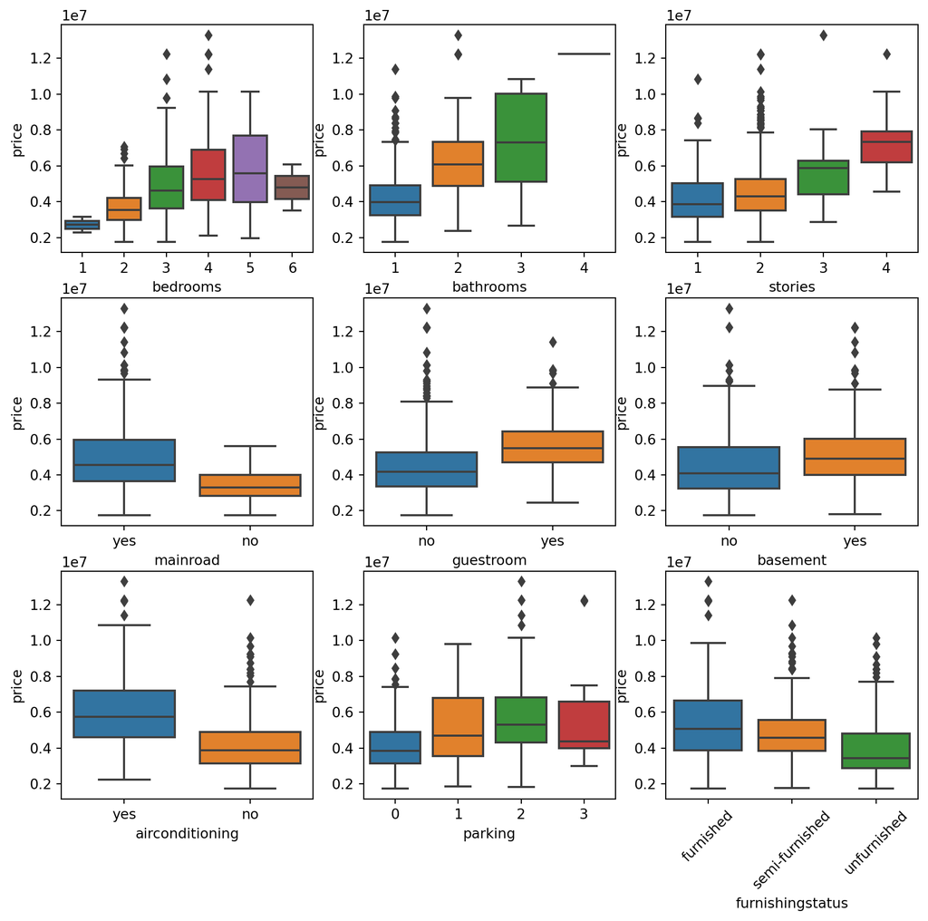

```python
plt.figure(figsize=(11, 10))
plt.subplot(3,3,1)
sns.boxplot(x = 'bedrooms', y = 'price', data = df1)

plt.subplot(3,3,2)
sns.boxplot(x = 'bathrooms', y = 'price', data = df1)

plt.subplot(3,3,3)
sns.boxplot(x = 'stories', y = 'price', data = df1)

plt.subplot(3,3,4)
sns.boxplot(x = 'mainroad', y = 'price', data = df1)

plt.subplot(3,3,5)
sns.boxplot(x = 'guestroom', y = 'price', data = df1)

plt.subplot(3,3,6)
sns.boxplot(x = 'basement', y = 'price', data = df1)


plt.subplot(3,3,7)
sns.boxplot(x = 'airconditioning', y = 'price', data = df1)

plt.subplot(3,3,8)
sns.boxplot(x = 'parking', y = 'price', data = df1)

plt.subplot(3,3,9)
sns.boxplot(x = 'furnishingstatus', y = 'price', data = df1)
# g.set_xticklabels(g.get_xticklabels(),rotation=45)
plt.xticks(
    rotation=45)

plt.show()
```

We can see that there exists oultiers. Therefore create multiple dataframes for different factors that remove the oulier by only remain the prices that is within the range of upper quarter+1.5*IQR and lower quarter-1.5*IQR of the level of the selected factors.

```python
# check boxplot for outlier
def is_outlier(s):
    Q1 = np.percentile(s, 25)

    Q3 = np.percentile(s, 75)
    IQR = Q3 - Q1

    upper=Q3+1.5*IQR

    lower=Q1-1.5*IQR

    return ~s.between(lower, upper)

# len(df1[~df1.groupby('furnishingstatus', group_keys=False)['price'].apply(is_outlier)])
```

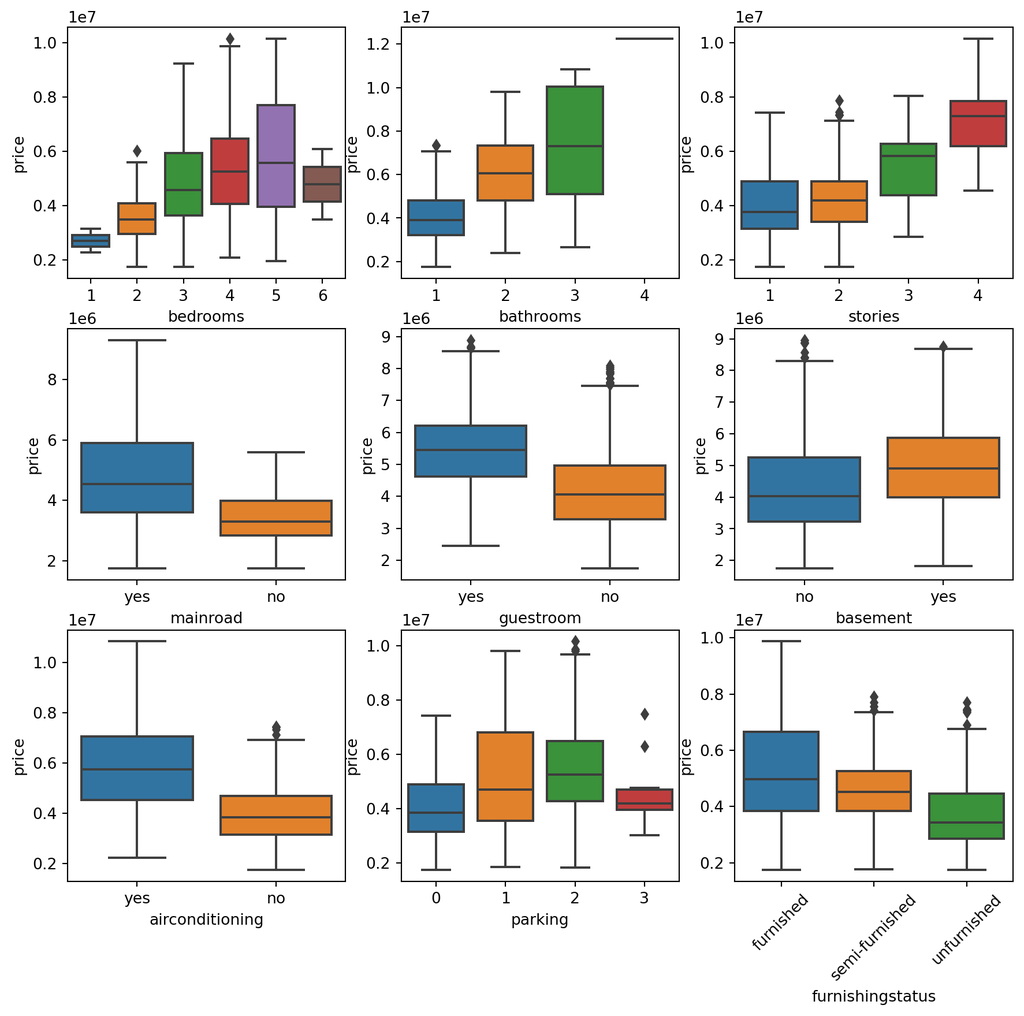

```python
plt.figure(figsize=(11, 10))

plt.subplot(3,3,1)
sns.boxplot(x = 'bedrooms', y = 'price', data = df1[~df1.groupby('bedrooms', group_keys=False)['price'].apply(is_outlier)])

plt.subplot(3,3,2)
sns.boxplot(x = 'bathrooms', y = 'price', data = df1[~df1.groupby('bathrooms', group_keys=False)['price'].apply(is_outlier)])

plt.subplot(3,3,3)
sns.boxplot(x = 'stories', y = 'price', data = df1[~df1.groupby('stories', group_keys=False)['price'].apply(is_outlier)])

plt.subplot(3,3,4)
sns.boxplot(x = 'mainroad', y = 'price', data = df1[~df1.groupby('mainroad', group_keys=False)['price'].apply(is_outlier)])

plt.subplot(3,3,5)
sns.boxplot(x = 'guestroom', y = 'price', data = df1[~df1.groupby('guestroom', group_keys=False)['price'].apply(is_outlier)])

plt.subplot(3,3,6)
sns.boxplot(x = 'basement', y = 'price', data = df1[~df1.groupby('basement', group_keys=False)['price'].apply(is_outlier)])


plt.subplot(3,3,7)
sns.boxplot(x = 'airconditioning', y = 'price', data = df1[~df1.groupby('airconditioning', group_keys=False)['price'].apply(is_outlier)])

plt.subplot(3,3,8)
sns.boxplot(x = 'parking', y = 'price', data = df1[~df1.groupby('parking', group_keys=False)['price'].apply(is_outlier)])

plt.subplot(3,3,9)
sns.boxplot(x = 'furnishingstatus', y = 'price', data = df1[~df1.groupby('furnishingstatus', group_keys=False)['price'].apply(is_outlier)])
plt.xticks(
    rotation=45)

plt.show()
```

Even though there still exists some outliers, the number of outliers reduce a lot, which means it’s has a relatively good performance.

### Result

In this part, the figure below shows the relationship between the housing price and certain factors like house area, bedrooms, furnished, nearness to mainroad, etc. The scatter plot is applied to show the relationship between the housing price and the area. The bar plot is used to show the average housing price for different level of the selected factors (all the factors other than area).

```python
fig = go.Figure()

# area
fig.add_trace(
    go.Scatter(
    x=df1_area["area"],
    y=df1_area["price"],
    mode="markers",
    visible=True)
    )

# bed room
fig.add_trace(
    go.Bar(
    x=df1_bed["bedrooms"],
    y=df1_bed["price"],
    visible=False)
    )

# bathrooms
fig.add_trace(
    go.Bar(
    x=df1_bath["bathrooms"],
    y=df1_bath["price"],
    visible=False)
    )

# stories
fig.add_trace(
    go.Bar(
    x=df1_stories["stories"],
    y=df1_stories["stories"],
    visible=False)
    )

# mainroad
fig.add_trace(
    go.Bar(
    x=df1_mainroad["mainroad"],
    y=df1_mainroad["price"],
    visible=False)
    )

# guestroom
fig.add_trace(
    go.Bar(
    x=df1_guestroom["guestroom"],
    y=df1_guestroom["price"],
    visible=False)
    )

# basement
fig.add_trace(
    go.Bar(
    x=df1_basement["basement"],
    y=df1_basement["price"],
    visible=False)
    )

# airconditioning
fig.add_trace(
    go.Bar(
    x=df1_air["airconditioning"],
    y=df1_air["price"],
    visible=False)
    )

# parking
fig.add_trace(
    go.Bar(
    x=df1_parking["parking"],
    y=df1_parking["price"],
    visible=False)
    )

# furnishingstatus
fig.add_trace(
    go.Bar(
    x=df1_fur["furnishingstatus"],
    y=df1_fur["price"],
    visible=False)
    )


# create buttom
buttons = []       # create a list for the buttons

for i in range(1,len(df1.columns)):
    visbility_list = [False] * (len(df1.columns)-1)
    visbility_list[i-1] = True
    buttons.append(
        dict(label=list(df1.columns)[i],
        method="update",
        args=[{"visible": visbility_list},
        {"title": list(df1.columns)[i],
        "xaxis": {"title": list(df1.columns)[i],
        "yaxis": "housing price"}}
        ]
        ))


# update the figure layout
fig.update_layout(
    template="plotly_white",
    xaxis_title="area",
    yaxis_title="housing price",
    title=go.layout.Title(
        text ="area",
        x=.1,
        y=.98),
)


x1_loc = 0
y1_loc = 1.2

# DROPDOWN MENUS
fig.update_layout(
    # DEFINE A LIST OF THE VARIOUS BUTTONS (STORED AS DICTIONARIES)
    updatemenus=[
        # BUTTON-1: OPACITY
        dict(
            # NOTICE THAT THE OPTION ARE A LIST OF DICTIONARIES
            # IMPORTANT: args specifies the key-value pairing for what to change
            buttons=buttons,
            # PLACEMENT AND META DATA FOR THE BUTTON
            direction="down",
            showactive=True,  # HIGHLIGHTS ACTIVE DROPDOWN ITEM OR ACTIVE BUTTON IF TRUE
            pad={"r": 10, "t": 10},  # PADDING
            x=x1_loc,  # POSITION
            y=y1_loc,
            xanchor="left",  # ANCHOR POINT
            yanchor="top",
        )
    ]
)


fig.show()
```

[interactive chart not shown]

From the graphs we can see that the housing price is almost positively correlated to all the factors. However, there are some factors that is not always positively correlated to the housing price. For the number of bedrooms, the average housing price is generally increasing as the number of bedrooms increases. But when the bedrooms is more than 4, the average housing price does not affected by the housing price. The average price of 4 and 5 is almost the same, and the price of 6 bedrooms is even getting lower. For basement, the average price of whether it has a basement or not does not have a huge difference. Therefore, it may not affect the housing price. For the number of parking, the average housing price with parking spaces is higher than no parking. However, there is no significant difference between the price of a house with two parking spaces and only one parking spaces, and the housing price of 3 parking spaces is even lower.

```python
df_house=df1.copy()

varlist =  ['mainroad', 'guestroom', 'basement', 'airconditioning']

# Defining the map function
def binary_map(x):
    return x.map({'yes': 1, "no": 0})

# Applying the function to the housing list
df_house[varlist] = df_house[varlist].apply(binary_map)

def fur_map(x):
    return x.map({'furnished': 0, "semi-furnished": 1, 'unfurnished': 2})

df_house[["furnishingstatus"]]=df_house[["furnishingstatus"]].apply(fur_map)
# df_house.head()
```

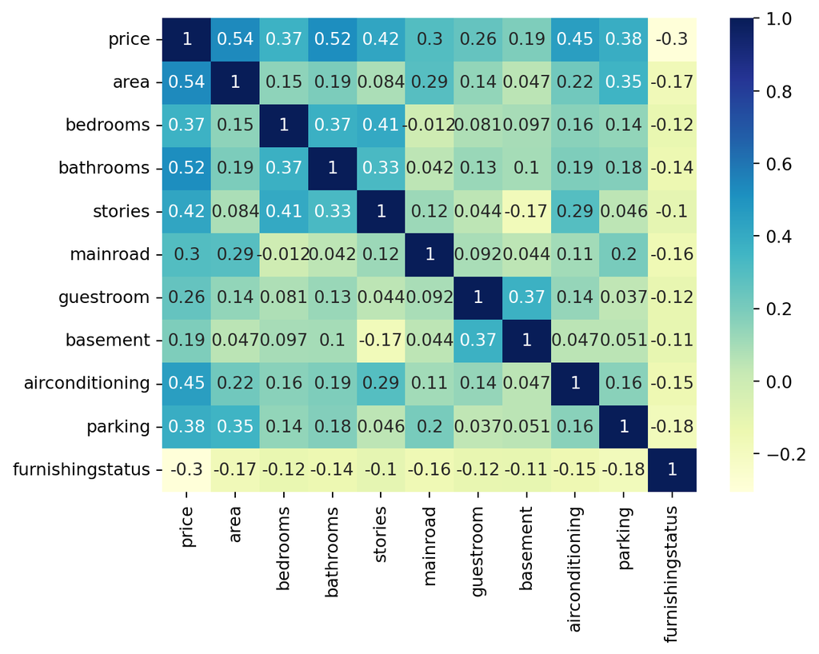

```python
sns.heatmap(df_house.corr(), annot = True, cmap="YlGnBu")
```

[output not shown]

## Annual Trends in Housing Prices by State in the US from 1975 to 2022

### Method

Firstly, calculate the average house index from 1975 to 2022 in each state. Then plot the bar plot that shows the mean of the house price indexes in each state from 1975 to 2022, and then sort the states in descending order based on the value of the house index. Finally use the line plot to show the trend of the house price index from 1975 to 2022 in each State.

### Result

```python
df2=pd.read_csv("../data/HPI_AT_state.csv",header = None)
df2.columns=['State','Year','Quarter','H_idx']
# df2.head()
```

```python
df2_year=df2[["State","Year","H_idx"]].groupby(["State","Year"]).mean().reset_index()
# df2_year
```

```python
# The bar plot
# make the bar can be selected, and selected based on the name od the appliances
selection = alt.selection_single(fields=['State'],name='Random')
color = alt.condition(selection,
                      alt.value('steelblue'),         # the selected bar's color is steelblue
                      alt.value('lightgray'))         # unselected bars is lightgray

bar=(alt.Chart(df2_year)
 .mark_bar()
 .encode(y='mean(H_idx):Q',            # y is the value of the sum of the power
         x=alt.X('State:N',            # x is the appliances, and each appliances is the sum of the power,
         sort=alt.EncodingSortField(field='H_idx', op='mean',
                            order='descending')),  # and they are in descending order according to the sum of the power
         color=color

        )
).add_selection(selection)           # the selection and the color are defined above

# set for the title, xlabel, and ylabel.
bar.title ="Mean of the House Price Indexes in each State in US from 1975 to 2022"
bar.encoding.x.title = 'State'
bar.encoding.y.title = 'Mean of the House Price Indexes'


# The corresponding line plot for the selected appliances.
color2 = alt.condition(selection,
                      alt.Color('State:N', legend=None),                # The color is based on the selected appliance
#                       alt.value('steelblue'),
                      alt.value('lightgray'))             # unselected is dark gray

line1=(alt.Chart(df2_year)
 .mark_line()                                                     # line plot
 .encode(x=alt.X('Year:O',axis=alt.Axis(labelAngle=-45)),          # x is the hour
         y='mean(H_idx):Q',                                      # y is the sum of the power
         color=color2,                                 # selection of the color is defined above
         opacity=alt.condition(selection, alt.value(1.0), alt.value(0.1))

        )
)

# set the title, x label, and y label
line1.title ="House Price Indexes in each State in US from 1975 to 2022"
line1.encoding.x.title = 'Year'
line1.encoding.y.title = 'House Price Indexes'

# plot horizontally
bar & line1
```

[interactive chart not shown]

The bar plot shows that the mean of the house price index of MA is the highest. It is because inflation, land costs, labor, and materials in MA. The mean of the house index in NY and DC is also pretty high. It is due to DC is the capital of the US and NY is the center of the US economy. The mean of the house price is the lowest in WV. That is because the population centers are relatively small, the tax base for services is lower in West Virginia than in other parts of the country.

The line plot clearly shows that for each state, the housing price index is in an increasing trend. But there is a short period of decreasing of house price index for most of states from 2007 to 2012, and then the house price index keeps increasing until now.

## Population & Salary

```python
df3= df2_year.copy()
df3_house=df3.loc[df3["Year"]==2022].reset_index(drop=True)
df3_house["State_long"]=df3_house["State"]

state_mapping = {
    'AK': 'Alaska', 'AL': 'Alabama', 'AR': 'Arkansas', 'AZ': 'Arizona', 'CA': 'California',
    'CO': 'Colorado', 'CT': 'Connecticut', 'DC': 'District of Columbia', 'DE': 'Delaware',
    'FL': 'Florida', 'GA': 'Georgia', 'HI': 'Hawaii', 'IA': 'Iowa', 'ID': 'Idaho',
    'IL': 'Illinois', 'IN': 'Indiana', 'KS': 'Kansas', 'KY': 'Kentucky', 'LA': 'Louisiana',
    'MA': 'Massachusetts', 'MD': 'Maryland', 'ME': 'Maine', 'MI': 'Michigan', 'MN': 'Minnesota',
    'MO': 'Missouri', 'MS': 'Mississippi', 'MT': 'Montana', 'NC': 'North Carolina', 'ND': 'North Dakota',
    'NE': 'Nebraska', 'NH': 'New Hampshire', 'NJ': 'New Jersey', 'NM': 'New Mexico', 'NV': 'Nevada',
    'NY': 'New York', 'OH': 'Ohio', 'OK': 'Oklahoma', 'OR': 'Oregon', 'PA': 'Pennsylvania',
    'RI': 'Rhode Island', 'SC': 'South Carolina', 'SD': 'South Dakota', 'TN': 'Tennessee', 'TX': 'Texas',
    'UT': 'Utah', 'VA': 'Virginia', 'VT': 'Vermont', 'WA': 'Washington', 'WI': 'Wisconsin',
    'WV': 'West Virginia', 'WY': 'Wyoming'
}

df3_house["State_long"]=df3_house["State_long"].map(state_mapping)
df3_house.rename(columns = {'H_idx':'Price_index'}, inplace = True)
# df3_house.head()
```

```python
df3_salary=pd.read_csv("../data/Salaries_2022.csv")
df3_salary.columns=["State_long","Average_Salary","Median_Salary"]

df3_population=pd.read_csv("../data/Population_2022.csv")
df3_population.columns=["State_long","FIPS_Code","Population"]

# df3_salary.head()
# df3_population.head()
```

Merge to create a new dataset

```python
from functools import reduce
df3_list=[df3_house,df3_population,df3_salary]
df3_use = reduce(lambda  left,right: pd.merge(left,right,on=['State_long'],how='outer'), df3_list)
df3_use['Population']=df3_use['Population'].str.replace('\W', '', regex=True)
df3_use['Average_Salary']=df3_use['Average_Salary'].str.replace('\W', '', regex=True)
df3_use['Median_Salary']=df3_use['Median_Salary'].str.replace('\W', '', regex=True)
df3_use["Price_index"]=round(df3_use["Price_index"],2)

df3_use['text1']= df3_use["State_long"]+ '<br>' + "Population: "+ df3_use["Population"].astype("str") + '<br>' + "Housing Price Index: "+ df3_use["Price_index"].astype("str")

df3_use['text2']= df3_use["State_long"]+ '<br>' + "Average Salary: "+ df3_use["Population"].astype("str") + '<br>' + "Housing Price Index: "+ df3_use["Price_index"].astype("str")
# df3_use.head()
```

```python
fig = go.Figure(
    data=go.Scattergeo(
        locationmode = 'USA-states',
        locations=df3_use['State'],
        text = df3_use['text1'],
        mode = 'markers',
        marker = dict(
            # size = np.log10(df3_use['Population'].astype("float")),   # log with base 10
            # size = 1.2*(df3_use['Population'].astype("float")/10000)**(1/3),
            size = (df3_use['Population'].astype("float")/100000)**(1/2), # set proper size
            opacity = 0.8,
            autocolorscale = False,
            # symbol = 'square',
            line = dict(
                width=1,
                color='rgba(102, 102, 102)'
            ),
            line_color='rgb(40,40,40)',
            color = round(df3_use["Price_index"],2),
            cmin = df3_use["Price_index"].min(),
            cmax = df3_use["Price_index"].max(),
            colorbar_title= "Housing Price Index"
        )
    )
)

fig.update_layout(
        title = 'Housing Price & Population in 2022<br>(Hover to see the information)',
        geo = dict(
            scope='usa',
            projection_type='albers usa',
            showland = True,
            landcolor = "rgb(250, 250, 250)",
            subunitcolor = "rgb(217, 217, 217)",
            countrycolor = "rgb(217, 217, 217)",
            countrywidth = 0.5,
            subunitwidth = 0.5
        )
    )

fig.show()
```

[interactive chart not shown]

```python
fig = go.Figure(
    data=go.Scattergeo(
        locationmode = 'USA-states',
        locations=df3_use['State'],
        text = df3_use['text2'],
        mode = 'markers',
        marker = dict(
            # size = np.log10(df3_use['Population'].astype("float")),   # log with base 10
            size = 0.5*((df3_use['Average_Salary'].astype("float")/10000)**(2)),  # set proper size
            opacity = 0.8,
            autocolorscale = False,
            # symbol = 'square',
            line = dict(
                width=1,
                color='rgba(102, 102, 102)'
            ),
            line_color='rgb(40,40,40)',
            color = round(df3_use["Price_index"],2),
            cmin = df3_use["Price_index"].min(),
            cmax = df3_use["Price_index"].max(),
            colorbar_title= "Housing Price Index"
        )
    )
)

fig.update_layout(
        title = 'Housing Price & Salaries in 2022<br>(Hover to see the information)',
        geo = dict(
            scope='usa',
            projection_type='albers usa',
            showland = True,
            landcolor = "rgb(250, 250, 250)",
            subunitcolor = "rgb(217, 217, 217)",
            countrycolor = "rgb(217, 217, 217)",
            countrywidth = 0.5,
            subunitwidth = 0.5
        )
    )

fig.show()
```

[interactive chart not shown]

Housing price in a state are almost positively correlated with the salaries in that state.

There appears to be a weak correlation between the housing price of a state and its population.

## Try to display the data table for the whole project

HTML_str 1 & 2

```python
import pandas as pd
from IPython.core.display import HTML

# Load the first dataset
df1 = pd.read_csv("../data/final_report/cleaned_state.csv")
num_pages1 = int(df1.shape[0] / 10) + 1

# Load the second dataset
df2 = pd.read_csv("../data/final_report/Housing.csv")
num_pages2 = int(df2.shape[0] / 10) + 1

# Load the third dataset
df3 = pd.read_csv("../data/final_report/crime_rate.csv")
num_pages3 = int(df3.shape[0] / 10) + 1

# Load the fourth dataset
df4 = pd.read_csv("../data/final_report/combined.csv")
num_pages4 = int(df4.shape[0] / 10) + 1

# Generate HTML for the first data table
html_str1 = f'''
<h3>Table 1: Housing Index by State for Different Quarters of the Year</h3>
<div id="table-container1"></div>

<script>
  var df1 = {df1.to_json(orient='records')};
  var page_size1 = 10;
  var current_page1 = 1;

  function show_table1() {{
    var start1 = (current_page1 - 1) * page_size1;
    var end1 = start1 + page_size1;
    var table_html1 = '<table><tr><th>' + Object.keys(df1[0]).join('</th><th>') + '</th></tr>';
    for (var i = start1; i < end1; i++) {{
      if (i >= df1.length) break;
      var row_html1 = '<tr><td>' + Object.values(df1[i]).join('</td><td>') + '</td></tr>';
      table_html1 += row_html1;
    }}
    table_html1 += '</table>';
    document.getElementById('table-container1').innerHTML = table_html1;
  }}

  function prev_page1() {{
    if (current_page1 > 1) {{
      current_page1--;
      show_table1();
    }}
  }}

  function next_page1() {{
    if (current_page1 < {num_pages1}) {{
      current_page1++;
      show_table1();
    }}
  }}

  show_table1();
</script>

<button onclick="prev_page1()">Previous Page</button>
<button onclick="next_page1()">Next Page</button>
'''

# Generate HTML for the second data table
html_str2 = f'''
<h3>Table 2: Intrinsic Factors for Higher Housing Price</h3>
<div id="table-container2"></div>

<script>
  var df2 = {df2.to_json(orient='records')};
  var page_size2 = 10;
  var current_page2 = 1;

  function show_table2() {{
    var start2 = (current_page2 - 1) * page_size2;
    var end2 = start2 + page_size2;
    var table_html2 = '<table><tr><th>' + Object.keys(df2[0]).join('</th><th>') + '</th></tr>';
    for (var i = start2; i < end2; i++) {{
      if (i >= df2.length) break;
      var row_html2 = '<tr><td>' + Object.values(df2[i]).join('</td><td>') + '</td></tr>';
      table_html2 += row_html2;
    }}
    table_html2 += '</table>';
    document.getElementById('table-container2').innerHTML = table_html2;
  }}
function prev_page2() {{
if (current_page2 > 1) {{
current_page2--;
show_table2();
}}
}}

function next_page2() {{
if (current_page2 < {num_pages2}) {{
current_page2++;
show_table2();
}}
}}

show_table2();
</script>

<button onclick="prev_page2()">Previous Page</button>
<button onclick="next_page2()">Next Page</button>
'''
```

HTML_str 3 & 4

```python
# Table 3
html_str3 = f'''

<h3>Table 3: Crime Data</h3>
<div id="table-container3"></div>
<script>
  var df3 = {df3.to_json(orient='records')};
  var page_size3 = 10;
  var current_page3 = 1;

  function show_table3() {{
    var start3 = (current_page3 - 1) * page_size3;
    var end3 = start3 + page_size3;
    var table_html3 = '<table><tr><th>' + Object.keys(df3[0]).join('</th><th>') + '</th></tr>';
    for (var i = start3; i < end3; i++) {{
      if (i >= df3.length) break;
      var row_html3 = '<tr><td>' + Object.values(df3[i]).join('</td><td>') + '</td></tr>';
      table_html3 += row_html3;
    }}
    table_html3 += '</table>';
    document.getElementById('table-container3').innerHTML = table_html3;
  }}

  function prev_page3() {{
    if (current_page3 > 1) {{
      current_page3--;
      show_table3();
    }}
  }}

  function next_page3() {{
    if (current_page3 < {num_pages3}) {{
      current_page3++;
      show_table3();
    }}
  }}

  show_table3();
</script>
<button onclick="prev_page3()">Previous Page</button>
<button onclick="next_page3()">Next Page</button>
'''

# Table 4
html_str4 = f'''

<h3>Table 4: Housing Price Index with Population and Salaries in 2022</h3>
<div id="table-container4"></div>
<script>
  var df4 = {df4.to_json(orient='records')};
  var page_size4 = 10;
  var current_page4 = 1;

  function show_table4() {{
    var start4 = (current_page4 - 1) * page_size4;
    var end4 = start4 + page_size4;
    var table_html4 = '<table><tr><th>' + Object.keys(df4[0]).join('</th><th>') + '</th></tr>';
    for (var i = start4; i < end4; i++) {{
      if (i >= df4.length) break;
      var row_html4 = '<tr><td>' + Object.values(df4[i]).join('</td><td>') + '</td></tr>';
      table_html4 += row_html4;
    }}
    table_html4 += '</table>';
    document.getElementById('table-container4').innerHTML = table_html4;
  }}

  function prev_page4() {{
    if (current_page4 > 1) {{
      current_page4--;
      show_table4();
    }}
  }}

function next_page4() {{
if (current_page4 < {num_pages4}) {{
current_page4++;
show_table4();
}}
}}

show_table4();
</script>

<button onclick="prev_page4()">Previous Page</button>
<button onclick="next_page4()">Next Page</button>
'''
```

Final Display the table

```python
final_html_str = f'''

<html>
<head>
  <style>
    table {{
      border-collapse: collapse;
      width: 100%;
    }}
    th, td {{
      text-align: left;
      padding: 8px;
    }}
    th {{
      background-color: #ddd;
    }}
    tr:nth-child(even) {{
      background-color: #f2f2f2;
    }}
    .page-buttons {{
      margin-top: 10px;
      margin-bottom: 10px;
    }}
  </style>
</head>
<body>
{html_str1}
{html_str2}
{html_str3}
{html_str4}
</body>
</html>
'''

display(HTML(final_html_str))
```

Table 1: Housing Index by State for Different Quarters of the Year

Table 2: Intrinsic Factors for Higher Housing Price

Table 3: Crime Data

Table 4: Housing Price Index with Population and Salaries in 2022